# Corporate Finance Assignment 5

Nitish Ramkumar

## Assignment 2

When I compare the final graph between both mine and Ian’s work, I am noticing very similar values, especially for returns at time 0.

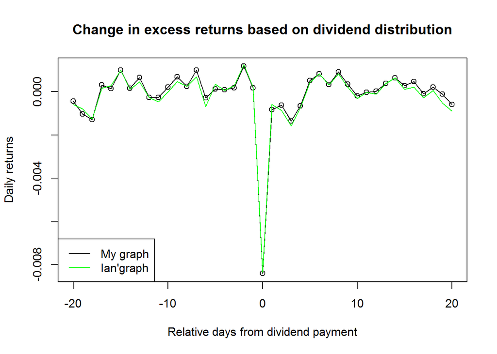

### Dataset building

To compare the data, lets create a dataset including PERMNO,YYYYMMDD,RET0 for both solutions

```
CompNoDateRet0.xRet0.y
1000120120111-0.023299903-0.023199250
1000120120213-0.005150850-0.004929688
1000120120313-0.028100057-0.027757727
1000120120411-0.021797869-0.021649954
1000120120511-0.002996039-0.002881669
1000120120613-0.007832087-0.007474527
```

### Comparison analysis

1. One difference which is obvious from the WRDS SQL query is that I have used vwretx of DSP500 to get risk free rate, whereas Ian has used vwretd for risk free rate. This should explain small differences on the daily 0th day returns.
2. There are also lesser number of dividend dates in my list than Ian’s. This is because
1. I have added an extra constraint while retrieving data out of DSEDIST, which is to take only distributions which have code = 1,2,5. These codes explicitly tell that the distribution are dividends.
2. Also to filter to year 2012, I have used payment date of dividends, where as Ian has used ex-dividend date.
3. If I compare the returns from the constructed datasets, I can see that for PERMNO < 13100 or PERMNO > 13500, the values seem very close between both the datasets

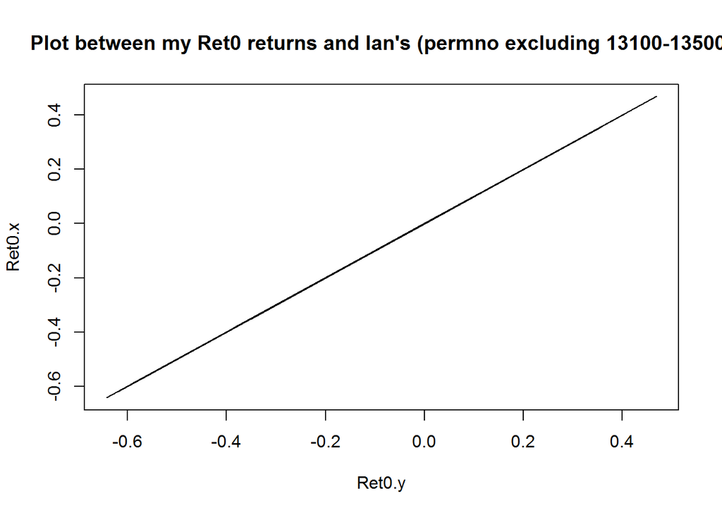

But for PERMNO between 13100 and 13500, there is a huge difference

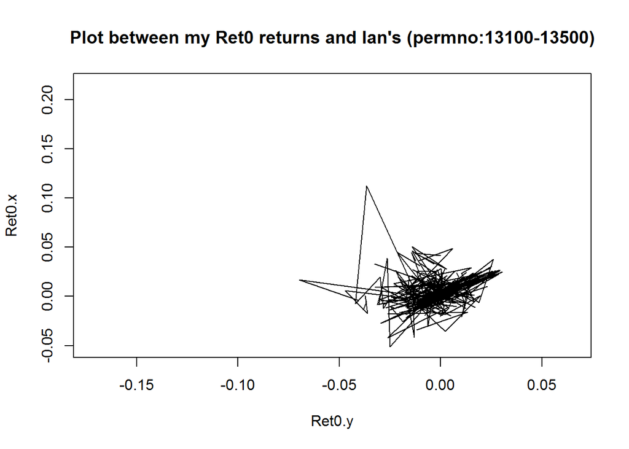

I have checked the dividend excluded returns retrieved for CRSP for these stocks and they are the same. So the difference is due to an error in processing of these returns.

### Reconciliation

1. Make sure same returns out of CRSP are used.
2. Follow similar practices for NA and null handling to avoid calculation differences.

### Learnings

1. Comment all possible assumptions which were made in order to make it easy for others to find out differences, without having to go through the code completely.

## Assignment 3

### Dataset building

To compare, lets build a PERM,YYYYMMDD,Ret table which has PERMNO starting with only 100. Sample of the merged dataset is:

```
PERMNOdateAnnualReturn.xMarketCap.xAnnualReturn.yMarketCap.y
1000120131231-0.0906928191759.22-0.1455016083929557
10001201412310.44274846113857.610.32142265115577765
10002201312310.03597128NANA332811410
1002520131231-0.10805332390254.77-0.114348921598190884
10025201412310.10070035215370.980.095946661922848867
10026201312310.400295281469231.360.3269641230318240
```

x is my data, and y is Forrest’s data.

### Comparison Analysis

**Returns**

If we see the plot of returns between the annualized returns of me and Forrest, we notice that it is not along the 45 degree line (green line).

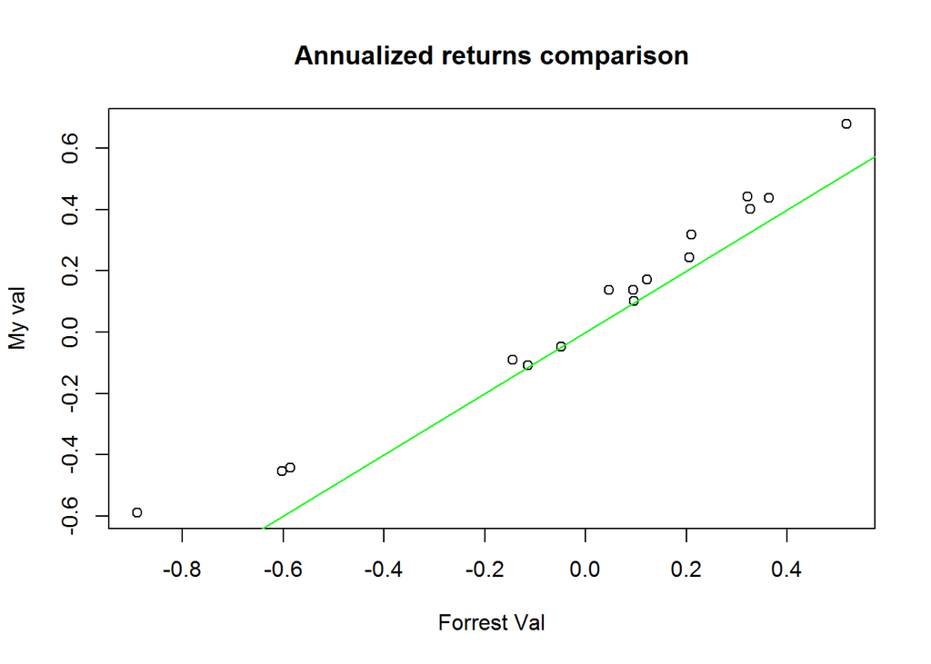

This difference in values is because Forrest has correctly maintained the log of returns in the Annual return column, whereas I have maintained the actual returns.

**MarketCap**

I didn’t multiply the value by 1000, which Forrest has correctly done. If we plot the market cap between the two datasets,

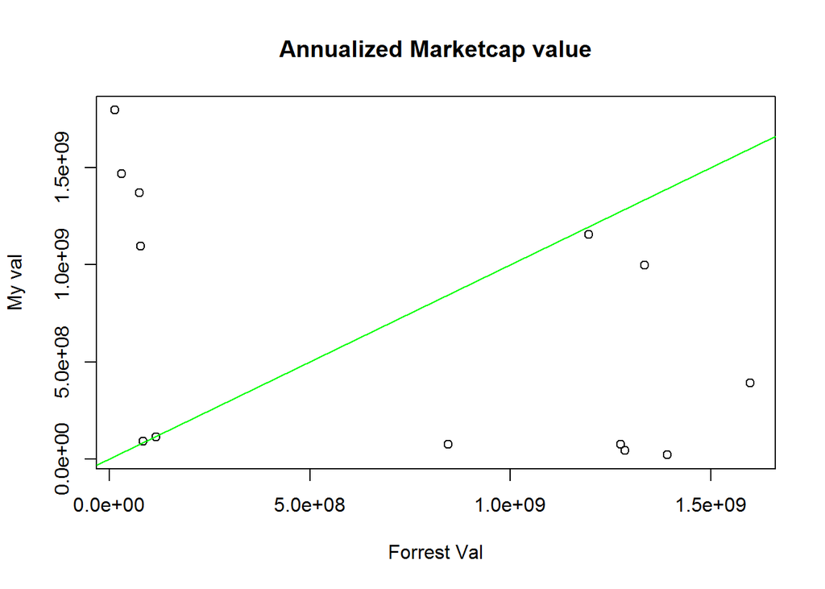

One reason I can point out for this is that I have taken annual market cap as average of all monthly market caps. Forrest has maintained the year end value as marketcap.

### Reconciliation

1. Both of us should use log returns
2. Use same standard for market cap value (either average or end of year value)

### R Code

```r
load("C:/_UCLA/237A_CorporateFinance/Assignments/MFE_237A_CorpFinance/Assignment2/total_data_withIan.RData")

plot(-20:20,stock.meanEventBasedReturns,xlab="Relative days from dividend payment",ylab="Daily returns",main = "Change in excess returns based on dividend distribution")
lines(-20:20,stock.meanEventBasedReturns)

lines(y=mean_vals,x=-20:20,col="green")

legend("bottomleft",lty=c(1,1), col=c("black","green"),c("My graph","Ian'graph"))

###Dataset building

#My solution
datasetForComparison_1 <- data.frame(CompNo=character(),Date=as.Date(character()),Ret0=numeric(),stringsAsFactors = FALSE)
for(compNo in colnames(stockReturnsMat)[-1]){
  allDividendDatesForCo <- stock.dividendEvents[stock.dividendEvents$PERMNO == compNo,"EXDT"]
  allStockInfo <- stockReturnsMat[,c("DATE",as.character(compNo))]
  dividendPositions <- sapply(allDividendDatesForCo,function(x){which(allStockInfo$DATE == x)})
  for(divPos in dividendPositions){
    if(length(divPos)>0){
          #PERMNO,Date,RET0 dataset
          newRow <- data.frame(CompNo=compNo,Date=as.Date(allStockInfo[divPos,1]),Ret0=allStockInfo[divPos,2],stringsAsFactors = FALSE)
          datasetForComparison_1 <- rbind(datasetForComparison_1,newRow)

      }
    }
  }


#Ian Solution
datasetForComparison_2 <- data.frame(CompNo=character(),Date=as.Date(character()),Ret0=numeric(),stringsAsFactors = FALSE)
for (m in 1:(ncol(S_reshaped) -1)){
  a=div_data[div_data$PERMNO==col_names[m],]
  a1=stocks[stocks$PERMNO==col_names[m],] ##specific stock returns...
  ##workable solution for only one stock on one day.. now try all days..
  for (j in 1:length(a$EXDT)){##iterates over all the dividend dates
    e=rownames(sp500[sp500$caldt==a$EXDT[j],])
    if(length(e)>0){
      e = as.numeric(e)
      f =a1$RETX[e]-sp500$vwretd[e]
      Newdata <- data.frame(CompNo=col_names[m],Date=as.Date(a$EXDT[j]),Ret0=f,stringsAsFactors = FALSE)
      datasetForComparison_2=rbind(datasetForComparison_2,Newdata)
    }
  }
}

datasetForComparison_1$Date <- format(datasetForComparison_1$Date,"%Y%m%d")
datasetForComparison_2$Date <- format(datasetForComparison_2$Date,"%Y%m%d")

suppressMessages(library(dplyr))
joined_data_1 <- datasetForComparison_2 %>% mutate(CompNo = as.character(CompNo)) %>% left_join(datasetForComparison_1,c("CompNo","Date"))
head(joined_data_1)

###Comparison analysis

joined_data_1 %>%
  filter(as.numeric(CompNo) < 13100 | as.numeric(CompNo) > 13500) %>%
  plot(Ret0.x~Ret0.y,.,type="l",main="Plot between my Ret0 returns and Ian's (permno excluding 13100-13500)")

joined_data_1 %>%
  filter(as.numeric(CompNo) >= 13100 & as.numeric(CompNo) <= 13500) %>%
  plot(Ret0.x~Ret0.y,.,type="l",main="Plot between my Ret0 returns and Ian's (permno:13100-13500)")

filtered_join_data_1 <- joined_data_1 %>% filter(as.numeric(CompNo) > 13100 & as.numeric(CompNo) < 13500) %>% na.omit

stockRetFiltered_1 <- stock.Returns[stock.Returns$PERMNO > 13100 &  stock.Returns$PERMNO < 13500,c("PERMNO","DATE","excessRet")]%>%arrange(PERMNO,DATE)%>%filter(PERMNO==13117)
stockRetFiltered_2 <- stocks[stocks$PERMNO > 13100 &  stocks$PERMNO < 13500,c("PERMNO","DATE","RETX")]%>%arrange(PERMNO,DATE)%>%filter(PERMNO==13117)

#ASSIGNMENT 3

###Dataset building

suppressMessages(library(dplyr))
suppressMessages(library(lubridate))
load("C:/_UCLA/237A_CorporateFinance/Assignments/MFE_237A_CorpFinance/Assignment2/total_data_withForrest.RData")

dataSetForComparision2_1 <- stock.annualReturns.WithTicker.Final %>% filter( PERMNO %/% 100 == 100 & date>='2013-01-01' & date<'2015-01-01')%>%select(PERMNO,date,AnnualReturn,MarketCap)
dataSetForComparision2_1$date <- as.numeric(format(dataSetForComparision2_1$date,"%Y%m%d"))

raw[,"Year"] <- paste0(raw[,"Year"],"12","31")
raw[,"PERMNO"] <- as.numeric(raw[,"PERMNO"])
raw[,"Year"] <- as.numeric(raw[,"Year"])
raw[,"Return"] <- as.numeric(raw[,"Return"])
raw[,"Market Cap"] <- as.numeric(raw[,"Market Cap"])
dataSetForComparision2_2 <- raw[,c("PERMNO","Year","Return","Market Cap")]
dataSetForComparision2_2 <- apply(dataSetForComparision2_2,2,unlist)
dataSetForComparision2_2 <- dataSetForComparision2_2[dataSetForComparision2_2[,"PERMNO"]%/%100==100,]
dataSetForComparision2_2 <- data.frame(dataSetForComparision2_2,stringsAsFactors = FALSE,row.names = NULL)
colnames(dataSetForComparision2_2) <- c("PERMNO","date","AnnualReturn","MarketCap")

joined <- dataSetForComparision2_1 %>% inner_join(dataSetForComparision2_2,by = c("PERMNO","date"))
head(joined)

###Comparison Analysis
plot(joined$AnnualReturn.x~joined$AnnualReturn.y,xlab="Forrest Val",ylab = "My val",main="Annualized returns comparison")
abline(0,1,col="green")

plot(joined$MarketCap.x*1000~joined$MarketCap.y,xlab="Forrest Val",ylab = "My val",xlim=c(30000000,1598000000),main="Annualized Marketcap value")
abline(0,1,col="green")
```